# NESE Post-Moult females: foraging strategies from behaviour and their isotopic niches

Luis Huckstadt

2026-11-10

# 1 Overview

A self-contained analysis, built from scratch, in two parts.

**Part A — Identify foraging strategies from behaviour.** Movement and diving variables only (19 variables). PCA → number of dimensions chosen by parallel analysis → HCPC (Ward + k-means consolidation). The number of strategies is chosen with explicit, data-driven rules: the gap statistic, a minimum cluster size, and bootstrap stability. Every choice is followed by a sensitivity check.

**Part B — Isotopic niches of those strategies.** Stable isotopes are **not** used in Part A, so they are an independent test of whether behaviourally defined strategies also differ in diet / foraging habitat: permutation tests, effect sizes, equivalence tests and Bayesian niche size and overlap (nicheROVER, SEA).

This is the Post-Moult version of `NESE_PB_ForagingStrategies.Rmd`: same variables, same rules, same tests, so the two trips are directly comparable. Differences from the Post-Breeding script: trips with impossible values are flagged and excluded, the number of strategies is left to the decision rule, a null-model test checks whether there is cluster structure at all, the “one more strategy?” check is generic (K vs K + 1), and strategies are compared with each seal’s Post-Breeding strategy.

All random steps are seeded. For a first test run, lower `N_BOOT`, `N_PERM`, `N_PA` and `N_POST` in the settings chunk.

```r
library(dplyr)
library(tidyr)
library(ggplot2)
library(FactoMineR)
library(factoextra)
library(cluster)     # clusGap, silhouette
# mclust is called as mclust::adjustedRandIndex (attaching it masks dplyr::count)
library(nicheROVER)
# MASS is called as MASS:: to avoid masking dplyr::select
```

# 2 Settings

```r
SEED <- 20261102
set.seed(SEED)

# Part A
N_DIM_OVERRIDE  <- NULL   # NULL = use parallel analysis; or set a number
K_OVERRIDE      <- NULL   # NULL = use the decision rule below; or set a number
EXCLUDE_INVALID <- TRUE   # drop trips with impossible values (percent > 100, proportion > 1)
N_NULL          <- 500    # simulations for the "is there cluster structure?" test
K_RANGE         <- 2:8    # candidate numbers of strategies
MIN_CLUSTER_N   <- 5      # smallest acceptable strategy (individuals)
MIN_JACCARD     <- 0.75   # every strategy must be at least "stable" (Hennig 2007)
N_PA            <- 1000   # parallel-analysis permutations
N_GAP           <- 200    # gap-statistic reference data sets
N_BOOT          <- 500    # bootstrap replicates for stability
SKEW_THRESHOLD  <- 1      # |skewness| above which variables are log-transformed in the sensitivity run

# Part B
N_PERM          <- 4999   # permutations for Freedman-Lane tests
N_POST          <- 1e4    # nicheROVER posterior draws
LOW_CONFIDENCE  <- 0.80   # seals with bootstrap co-assignment below this are "low confidence"

# SIBER (needs JAGS installed: https://mcmc-jags.sourceforge.io, then install.packages(c("rjags", "SIBER")))
SIBER_PARMS  <- list(n.iter = 2e4, n.burnin = 1e3, n.thin = 10, n.chains = 2)
SIBER_PRIORS <- list(R = 1 * diag(2), k = 2, tau.mu = 1.0E-3)   # SIBER defaults
SIBER_DRAWS  <- 500      # posterior draws used for Bayesian ellipse overlap
SIBER_P      <- 0.95     # ellipse used for overlap (0.95 = 95% ellipse; NULL = standard ellipse)
HAS_SIBER <- requireNamespace("SIBER", quietly = TRUE) && requireNamespace("rjags", quietly = TRUE)
if (!HAS_SIBER) message("SIBER/rjags (JAGS) not available: the SIBER section will be skipped.")

# Equivalence margins (permil): differences smaller than these are considered
# ecologically negligible. Biological judgement - justify in the paper.
EQUIV <- c(d13C = 0.3, d15N = 1.0)

OUT <- "../results/PM_strategies"
FIG <- "../figures/PM_strategies"
# Post-Breeding assignments (from NESE_PB_ForagingStrategies.Rmd), for the PB-PM comparison
PB_ASSIGNMENTS <- "../results/PB_strategies/A_strategy_assignments.csv"
dir.create(OUT, recursive = TRUE, showWarnings = FALSE)
dir.create(FIG, recursive = TRUE, showWarnings = FALSE)

PAL <- c("#1b9e77", "#d95f02", "#7570b3", "#e7298a", "#66a61e", "#e6ab02", "#a6761d", "#666666")
```

# 3 Data

```r
SPACE <- c("MaxLat_degrees", "MinLon_degrees",
           "MedianDistToContShelf_km", "SdDistContShelf_km",
           "MesoEcoProportionShelf", "MesoEcoProportionCAC",
           "MesoEcoProportionSubArcticPac", "MesoEcoProportionNorthCPac")
DIVE  <- c("Mean_Depth_m", "Mean_Depth_sd", "Mean_Duration_sec", "Mean_Duration_sd",
           "Pct_TransitDives", "Pct_ForagingDives", "Pct_DriftDives", "Pct_BenthicDives",
           "PctTripDiving", "DeepDayForageDivesMedian_m", "DeepNightForageDivesMedian_m")
BEHAV <- c(SPACE, DIVE)
ISO   <- c("d13C", "d15N")
REGIONS <- c(MesoEcoProportionShelf        = "Shelf",
             MesoEcoProportionCAC          = "California Current",
             MesoEcoProportionSubArcticPac = "Subarctic",
             MesoEcoProportionNorthCPac    = "North Central Pacific")
```

```r
meta <- read.csv("../data/IsotopesDatasetForLuis_2023_4_4.csv") %>%
  transmute(TOPPID = as.character(TOPPID), MainID = as.character(MainID),
            TripDuration_days, MassGainRate_kgPerDay_Dcrocker) %>%
  distinct(TOPPID, .keep_all = TRUE)

dat <- readRDS("../data/f.PCAdata.1.rds") %>%
  mutate(TOPPID = as.character(TOPPID)) %>%
  filter(Trip == "PostMolt") %>%
  left_join(meta, by = "TOPPID") %>%
  mutate(ProcedureYear = factor(ProcedureYear)) %>%
  as.data.frame()
rownames(dat) <- dat$TOPPID

stopifnot(all(c(BEHAV, ISO) %in% names(dat)), !anyDuplicated(dat$TOPPID))
cat("Rows with missing behavioural data:", sum(!complete.cases(dat[BEHAV])), "\n")
```

```
## Rows with missing behavioural data: 0
```

```r
dat <- dat[complete.cases(dat[BEHAV]), ]
n <- nrow(dat)
cat(n, "Post-Moult trips from", n_distinct(dat$MainID, na.rm = TRUE), "seals\n")
```

```
## 87 Post-Moult trips from 83 seals
```

```r
table(dat$ProcedureYear)
```

```
##
## 2008 2009 2012 2013 2014 2015 2016 2017
##   11    9   13   15   14    3   11   11
```

The unit of analysis is the **trip**. Seals tracked in more than one year contribute more than one trip; this is checked in the sensitivity analyses (one trip per seal).

```r
dat %>% filter(!is.na(MainID)) %>% dplyr::count(MainID) %>% filter(n > 1)
```

```
##   MainID n
## 1   4534 2
## 2   T220 2
## 3   U634 2
## 4  WX311 2
```

## 3.1 Data checks

```r
# 0. Impossible values: percentages outside 0-100, proportions outside 0-1.
#    Check these trips in the raw data; by default they are excluded.
pct_vars  <- grep("^Pct", BEHAV, value = TRUE)
prop_vars <- names(REGIONS)
bad <- dat %>% dplyr::select(TOPPID, all_of(c(pct_vars, prop_vars))) %>%
  pivot_longer(-TOPPID, names_to = "variable") %>%
  filter((variable %in% pct_vars  & (value < 0 | value > 100)) |
         (variable %in% prop_vars & (value < 0 | value > 1)))
bad
```

```
## # A tibble: 1 × 3
##   TOPPID  variable      value
##   <chr>   <chr>         <dbl>
## 1 2013035 PctTripDiving  148.
```

```r
if (EXCLUDE_INVALID && nrow(bad) > 0) {
  dat <- dat[!dat$TOPPID %in% bad$TOPPID, ]
  n <- nrow(dat)
  cat("Excluded", n_distinct(bad$TOPPID), "trip(s) with impossible values; n =", n, "\n")
}
```

```
## Excluded 1 trip(s) with impossible values; n = 86
```

```r
# 1. Mesoecoregion proportions are compositional (they sum to 1), so one of the
#    four is redundant. PCA handles the exact linear dependence (one zero eigenvalue).
summary(rowSums(dat[names(REGIONS)]))
```

```
##    Min. 1st Qu.  Median    Mean 3rd Qu.    Max.
##       1       1       1       1       1       1
```

```r
# 2. Dive-type percentages: check their definition if they do not sum to ~100
summary(rowSums(dat[c("Pct_TransitDives", "Pct_ForagingDives",
                      "Pct_DriftDives", "Pct_BenthicDives")]))
```

```
##    Min. 1st Qu.  Median    Mean 3rd Qu.    Max.
##   63.01   88.44   95.53   92.46   97.10   98.90
```

```r
# 3. Skewness (PCA and Ward are least-squares methods, sensitive to long tails)
skew <- function(x) { z <- (x - mean(x)) / sd(x); mean(z^3) }
sort(round(sapply(dat[BEHAV], skew), 2))
```

```
##                  Mean_Depth_m             Mean_Duration_sec
##                         -1.00                         -0.65
##      MedianDistToContShelf_km MesoEcoProportionSubArcticPac
##                         -0.54                         -0.48
##             Pct_ForagingDives            SdDistContShelf_km
##                         -0.40                         -0.31
##  DeepNightForageDivesMedian_m                 PctTripDiving
##                         -0.31                         -0.14
##              Mean_Duration_sd                MinLon_degrees
##                          0.18                          0.28
##              Pct_TransitDives    MesoEcoProportionNorthCPac
##                          0.56                          0.67
##    DeepDayForageDivesMedian_m                MaxLat_degrees
##                          0.76                          0.96
##                 Mean_Depth_sd              Pct_BenthicDives
##                          0.96                          1.82
##                Pct_DriftDives          MesoEcoProportionCAC
##                          2.13                          2.49
##        MesoEcoProportionShelf
##                          5.15
```

```r
# 4. Strongly redundant pairs (|Spearman rho| > 0.85) give extra weight to one axis
rho <- cor(dat[BEHAV], method = "spearman"); rho[upper.tri(rho, diag = TRUE)] <- NA
as.data.frame(as.table(rho)) %>% filter(abs(Freq) > 0.85) %>% arrange(desc(abs(Freq)))
```

```
##                            Var1                          Var2       Freq
## 1    MesoEcoProportionNorthCPac MesoEcoProportionSubArcticPac -0.9257633
## 2    MesoEcoProportionNorthCPac      MedianDistToContShelf_km  0.8814396
## 3 MesoEcoProportionSubArcticPac                MaxLat_degrees  0.8571415
```

# 4 Part A — Foraging strategies from behaviour

## 4.1 Helper functions

```r
pc_scores <- function(X, nd) prcomp(X, center = TRUE, scale. = TRUE)$x[, 1:nd, drop = FALSE]

# Ward + k-means consolidation from the Ward centroids (= FactoMineR::HCPC),
# fast enough for bootstrap loops
hcpc_lite <- function(S, k) {
  cl  <- cutree(hclust(dist(S), method = "ward.D2"), k)
  cen <- apply(S, 2, function(x) tapply(x, cl, mean))
  tryCatch(kmeans(S, centers = cen, iter.max = 100)$cluster,
           error = function(e) cl)   # if consolidation empties a cluster, keep Ward
}

# HCPC's own rule for suggesting k: minimise W(k)/W(k-1)
hcpc_ratio <- function(S, ks) {
  h <- hclust(dist(S), method = "ward.D2")
  g <- sort(h$height^2 / (2 * nrow(S)), decreasing = TRUE)
  W <- sapply(1:(max(ks) + 1), function(k) sum(g[k:length(g)]))
  setNames(W[ks] / W[ks - 1], ks)
}

# Whole-pipeline bootstrap: resample seals, redo PCA + clustering.
# Returns mean Jaccard per cluster and, per seal, the proportion of resamples in
# which it stays with its full-data cluster mates (co-assignment).
boot_stability <- function(X, nd, k, B = N_BOOT) {
  ref <- hcpc_lite(pc_scores(X, nd), k); m <- nrow(X)
  J <- matrix(NA, B, k)
  co <- seen <- numeric(m)
  for (b in 1:B) {
    ix <- unique(sample(m, replace = TRUE))
    cb <- hcpc_lite(pc_scores(X[ix, , drop = FALSE], nd), k)
    for (cc in 1:k) {
      A <- ix[ref[ix] == cc]
      if (length(A)) J[b, cc] <- max(sapply(unique(cb), function(j) {
        Bj <- ix[cb == j]; length(intersect(A, Bj)) / length(union(A, Bj)) }))
    }
    lab <- setNames(cb, ix)
    for (i in ix) {
      mates <- setdiff(ix[ref[ix] == ref[i]], i)
      if (length(mates)) {
        co[i] <- co[i] + mean(lab[as.character(mates)] == lab[as.character(i)])
        seen[i] <- seen[i] + 1
      }
    }
  }
  list(ref = ref, jaccard = colMeans(J, na.rm = TRUE), coassign = co / pmax(seen, 1))
}
```

## 4.2 PCA and number of dimensions

The number of dimensions is chosen by **Horn’s parallel analysis**: keep a dimension only if its eigenvalue exceeds the 95th percentile of eigenvalues from data with the same variables but no correlation among them (each column permuted independently). Kaiser, cumulative variance and broken stick are shown for comparison.

```r
X <- dat[BEHAV]
res.pca.full <- PCA(X, ncp = 10, graph = FALSE)
# Eigenvalues of the correlation matrix (identical to FactoMineR's standardised PCA)
eig <- pmax(eigen(cor(X), symmetric = TRUE, only.values = TRUE)$values, 0)
p <- length(eig)

pa <- apply(replicate(N_PA, eigen(cor(apply(X, 2, sample)), symmetric = TRUE,
                                  only.values = TRUE)$values), 1, quantile, 0.95)
bs <- sapply(1:p, function(k) sum(1 / (k:p)))

pc_tab <- data.frame(dim = 1:p, eigenvalue = eig, pct_var = 100 * eig / sum(eig),
                     cum_pct = 100 * cumsum(eig) / sum(eig), parallel_95 = pa, broken_stick = bs)
round(head(pc_tab, 10), 3)
```

```
##    dim eigenvalue pct_var cum_pct parallel_95 broken_stick
## 1    1      5.367  28.246  28.246       2.123        3.548
## 2    2      2.584  13.597  41.843       1.874        2.548
## 3    3      2.209  11.626  53.469       1.702        2.048
## 4    4      1.916  10.084  63.553       1.568        1.714
## 5    5      1.380   7.261  70.814       1.449        1.464
## 6    6      1.203   6.334  77.147       1.338        1.264
## 7    7      0.845   4.448  81.595       1.247        1.098
## 8    8      0.725   3.816  85.412       1.163        0.955
## 9    9      0.688   3.621  89.033       1.078        0.830
## 10  10      0.509   2.678  91.711       0.995        0.719
```

```r
rules <- c(`Parallel analysis (95%)` = which(eig <= pa)[1] - 1,
           `Broken stick`            = which(eig <= bs)[1] - 1,
           `Kaiser (eigenvalue > 1)` = sum(eig > 1),
           `Cumulative >= 75%`       = which(pc_tab$cum_pct >= 75)[1])
rules
```

```
## Parallel analysis (95%)            Broken stick Kaiser (eigenvalue > 1)
##                       4                       4                       6
##       Cumulative >= 75%
##                       6
```

```r
N_DIM <- if (is.null(N_DIM_OVERRIDE)) max(2, rules[["Parallel analysis (95%)"]]) else N_DIM_OVERRIDE
cat("Dimensions retained: N_DIM =", N_DIM, "(", round(pc_tab$cum_pct[N_DIM], 1), "% of variance )\n")
```

```
## Dimensions retained: N_DIM = 4 ( 63.6 % of variance )
```

```r
write.csv(pc_tab, file.path(OUT, "A_pca_dimensions.csv"), row.names = FALSE)
```

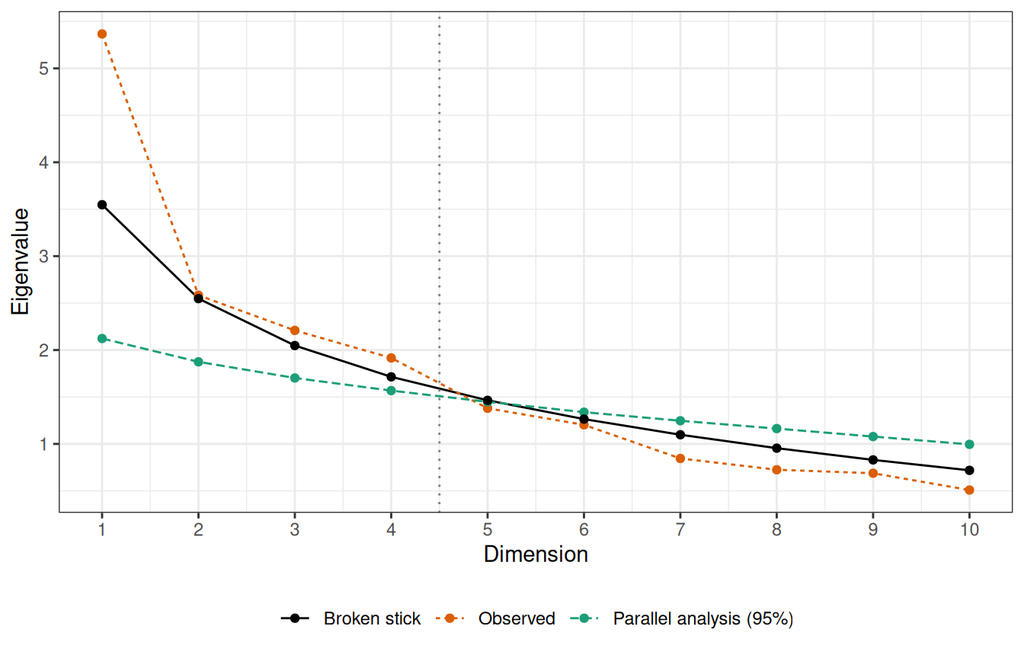

```r
g <- pc_tab %>% filter(dim <= 10) %>%
  pivot_longer(c(eigenvalue, parallel_95, broken_stick)) %>%
  mutate(name = recode(name, eigenvalue = "Observed", parallel_95 = "Parallel analysis (95%)",
                       broken_stick = "Broken stick")) %>%
  ggplot(aes(dim, value, colour = name, linetype = name)) + geom_line() + geom_point() +
  geom_vline(xintercept = N_DIM + 0.5, colour = "grey50", linetype = 3) +
  scale_x_continuous(breaks = 1:10) +
  scale_colour_manual(values = c("black", "#d95f02", "#1b9e77")) +
  labs(x = "Dimension", y = "Eigenvalue", colour = NULL, linetype = NULL) +
  theme_bw() + theme(legend.position = "bottom")
g
```

```r
ggsave(file.path(FIG, "A_pca_dimensions.pdf"), g, width = 7, height = 4.5)
```

### 4.2.1 What the dimensions represent

Correlations between variables and dimensions (unrotated; these are the axes used for clustering). Only the first two axes are usually stable enough to be interpreted one by one — describe strategies with the original variables (below) rather than by individual dimensions.

```r
round(res.pca.full$var$cor[, 1:N_DIM], 2)
```

```
##                               Dim.1 Dim.2 Dim.3 Dim.4
## MaxLat_degrees                -0.88  0.03  0.01  0.06
## MinLon_degrees                -0.25 -0.62  0.00  0.14
## MedianDistToContShelf_km       0.87  0.32 -0.07 -0.06
## SdDistContShelf_km             0.70  0.28  0.02 -0.44
## MesoEcoProportionShelf        -0.07 -0.19  0.18 -0.16
## MesoEcoProportionCAC           0.11 -0.63 -0.03 -0.13
## MesoEcoProportionSubArcticPac -0.86  0.10 -0.19  0.32
## MesoEcoProportionNorthCPac     0.86  0.12  0.18 -0.28
## Mean_Depth_m                   0.51 -0.23 -0.56  0.51
## Mean_Depth_sd                  0.19  0.58 -0.43  0.15
## Mean_Duration_sec              0.51  0.17  0.44  0.60
## Mean_Duration_sd               0.39  0.24  0.39  0.55
## Pct_TransitDives              -0.28  0.28 -0.75 -0.02
## Pct_ForagingDives              0.56 -0.65  0.28  0.07
## Pct_DriftDives                -0.22  0.23  0.18  0.04
## Pct_BenthicDives              -0.37  0.53  0.33 -0.11
## PctTripDiving                 -0.27  0.14  0.39  0.59
## DeepDayForageDivesMedian_m    -0.62 -0.15  0.43 -0.30
## DeepNightForageDivesMedian_m  -0.22  0.46  0.38 -0.25
```

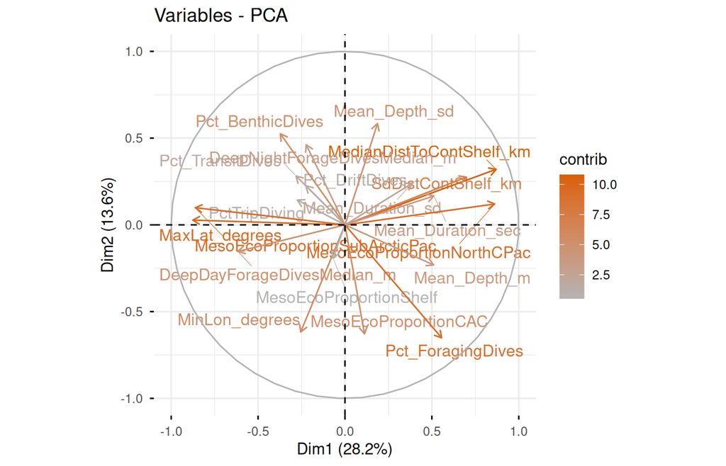

```r
fviz_pca_var(res.pca.full, repel = TRUE, col.var = "contrib",
             gradient.cols = c("grey70", "#d95f02"))
```

## 4.3 Number of strategies

Candidate solutions k = 2–8 are compared with:

- **Gap statistic** (Tibshirani et al. 2001, 1-SE rule): compares within-cluster dispersion with that of structureless reference data.
- **HCPC’s own rule** (minimum within-inertia ratio), shown for information.
- **Mean silhouette** and **minimum cluster size**.
- **Bootstrap stability**: mean Jaccard similarity of each cluster across 500 resamples of the whole pipeline.

**Decision rule.** Take the k suggested by the gap statistic, provided every strategy has ≥ `MIN_CLUSTER_N` seals and a mean Jaccard ≥ `MIN_JACCARD`. Otherwise take the largest k below it that meets both conditions.

```r
S <- res.pca.full$ind$coord[, 1:N_DIM]

gs <- clusGap(S, FUNcluster = function(x, k) list(cluster = hcpc_lite(x, k)),
              K.max = max(K_RANGE), B = N_GAP, spaceH0 = "scaledPCA", verbose = FALSE)
k_gap <- maxSE(gs$Tab[, "gap"], gs$Tab[, "SE.sim"], method = "Tibs2001SEmax")
hr <- hcpc_ratio(S, K_RANGE)

stab <- lapply(K_RANGE, function(k) { set.seed(SEED); boot_stability(X, N_DIM, k) })
names(stab) <- K_RANGE

k_tab <- data.frame(
  k = K_RANGE,
  gap = gs$Tab[K_RANGE, "gap"], gap_se = gs$Tab[K_RANGE, "SE.sim"],
  hcpc_ratio = hr,
  silhouette = sapply(K_RANGE, function(k) mean(silhouette(hcpc_lite(S, k), dist(S))[, 3])),
  sizes = sapply(stab, function(s) paste(sort(table(s$ref), decreasing = TRUE), collapse = "/")),
  min_size = sapply(stab, function(s) min(table(s$ref))),
  min_jaccard = sapply(stab, function(s) min(s$jaccard)),
  row.names = NULL)
k_tab$passes <- k_tab$min_size >= MIN_CLUSTER_N & k_tab$min_jaccard >= MIN_JACCARD
k_tab %>% mutate(across(where(is.double), ~ round(.x, 3)))
```

```
##   k   gap gap_se hcpc_ratio silhouette              sizes min_size min_jaccard
## 1 2 0.525  0.027      0.715      0.301              48/38       38       0.908
## 2 3 0.515  0.029      0.839      0.318           47/26/13       13       0.704
## 3 4 0.473  0.030      0.859      0.320          47/25/9/5        5       0.309
## 4 5 0.494  0.028      0.859      0.294        40/24/9/8/5        5       0.480
## 5 6 0.513  0.028      0.850      0.250     25/23/16/9/8/5        5       0.544
## 6 7 0.495  0.028      0.887      0.257   25/24/14/8/8/5/2        2       0.431
## 7 8 0.481  0.029      0.903      0.262 25/24/14/8/7/5/2/1        1       0.553
##   passes
## 1   TRUE
## 2  FALSE
## 3  FALSE
## 4  FALSE
## 5  FALSE
## 6  FALSE
## 7  FALSE
```

```r
write.csv(k_tab, file.path(OUT, "A_number_of_strategies.csv"), row.names = FALSE)

ok <- k_tab$k[k_tab$passes]
K_SUGGESTED <- if (k_gap %in% ok) k_gap else if (any(ok < k_gap)) max(ok[ok < k_gap]) else min(K_RANGE)
K <- if (is.null(K_OVERRIDE)) K_SUGGESTED else K_OVERRIDE
cat("Gap statistic suggests k =", k_gap, "; HCPC rule suggests k =", names(which.min(hr)),
    "; decision rule gives K =", K_SUGGESTED, "; using K =", K, "\n")
```

```
## Gap statistic suggests k = 2 ; HCPC rule suggests k = 2 ; decision rule gives K = 2 ; using K = 2
```

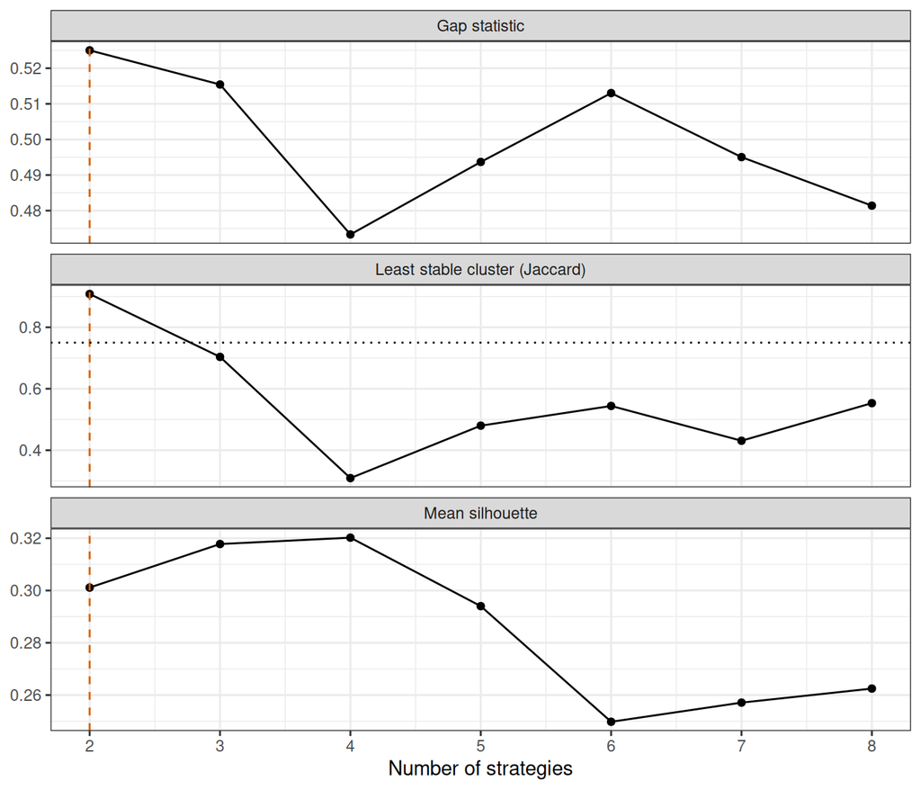

```r
kp <- k_tab %>% dplyr::select(k, gap, silhouette, min_jaccard) %>%
  pivot_longer(-k) %>%
  mutate(name = recode(name, gap = "Gap statistic", silhouette = "Mean silhouette",
                       min_jaccard = "Least stable cluster (Jaccard)"))
g <- ggplot(kp, aes(k, value)) + geom_line() + geom_point() +
  geom_vline(xintercept = K, colour = "#d95f02", linetype = 2) +
  geom_hline(data = data.frame(name = "Least stable cluster (Jaccard)", y = MIN_JACCARD),
             aes(yintercept = y), linetype = 3) +
  facet_wrap(~ name, ncol = 1, scales = "free_y") +
  scale_x_continuous(breaks = K_RANGE) + theme_bw() + labs(x = "Number of strategies", y = NULL)
g
```

```r
ggsave(file.path(FIG, "A_number_of_strategies.pdf"), g, width = 6, height = 7)
```

## 4.4 Is there cluster structure at all?

Clustering always returns groups, even from a continuum. Here the observed silhouette is compared with that obtained by applying the same clustering to 500 data sets simulated from a single multivariate normal distribution with the observed variance on each retained dimension (no groups). A p-value near or above 0.05 means the strategies are weakly separated and should be described as modes of a continuum rather than discrete groups.

```r
sds <- apply(S, 2, sd)
set.seed(SEED)
null_struct <- do.call(rbind, lapply(intersect(2:4, K_RANGE), function(k) {
  obs <- mean(silhouette(hcpc_lite(S, k), dist(S))[, 3])
  sim <- replicate(N_NULL, {
    Y <- sapply(sds, function(s) rnorm(nrow(S), 0, s))
    mean(silhouette(hcpc_lite(Y, k), dist(Y))[, 3])
  })
  data.frame(k = k, silhouette = obs, null_median = median(sim),
             null_95 = quantile(sim, 0.95), p = (1 + sum(sim >= obs)) / (N_NULL + 1))
}))
rownames(null_struct) <- NULL
null_struct %>% mutate(across(where(is.double), ~ round(.x, 3)))
```

```
##   k silhouette null_median null_95     p
## 1 2      0.301       0.254   0.297 0.040
## 2 3      0.318       0.214   0.251 0.002
## 3 4      0.320       0.212   0.243 0.002
```

```r
write.csv(null_struct, file.path(OUT, "A_null_structure_test.csv"), row.names = FALSE)
```

## 4.5 Would one more strategy be justified? (K vs K + 1)

When two solutions are close, the choice should rest on (i) whether the finer solution is a refinement of the coarser one, (ii) whether the extra group is reproducible, and (iii) whether it differs in variables that were **not** used to build the clusters (external validation; Hennig 2015, *Pattern Recognition Letters* 64:53–62).

### 4.5.1 1. What the gap statistic says

The 1-SE rule picks the *smallest* k whose gap is within one standard error of the next; it is deliberately conservative. Other standard rules are shown for comparison.

```r
K_HI <- K + 1
sapply(c("Tibs2001SEmax", "firstSEmax", "firstmax", "globalSEmax", "globalmax"),
       function(m) maxSE(gs$Tab[, "gap"], gs$Tab[, "SE.sim"], method = m))
```

```
## Tibs2001SEmax    firstSEmax      firstmax   globalSEmax     globalmax
##             2             2             2             2             2
```

```r
k_tab %>% filter(k %in% (K - 1):(K + 2)) %>%
  dplyr::select(k, gap, gap_se, silhouette, sizes, min_size, min_jaccard, passes) %>%
  mutate(across(where(is.double), ~ round(.x, 3)))
```

```
##   k   gap gap_se silhouette     sizes min_size min_jaccard passes
## 1 2 0.525  0.027      0.301     48/38       38       0.908   TRUE
## 2 3 0.515  0.029      0.318  47/26/13       13       0.704  FALSE
## 3 4 0.473  0.030      0.320 47/25/9/5        5       0.309  FALSE
```

### 4.5.2 2. Is K + 1 a refinement of K, and is the extra group stable?

```r
stopifnot(as.character(K_HI) %in% names(stab))
l_lo <- stab[[as.character(K)]]$ref; l_hi <- stab[[as.character(K_HI)]]$ref
table(`K` = l_lo, `K + 1` = l_hi)
```

```
##    K + 1
## K    1  2  3
##   1 12  1 25
##   2  1 46  1
```

```r
new_grp   <- as.integer(names(which.min(table(l_hi))))                  # smallest group at K + 1
parent    <- as.integer(names(which.max(table(l_lo[l_hi == new_grp])))) # K cluster it comes from
in_parent <- l_lo == parent
split_grp <- l_hi == new_grp & in_parent
cat("K + 1 =", K_HI, "separates", sum(split_grp), "seals from a cluster of", sum(in_parent),
    "; Jaccard stability of that group:", round(stab[[as.character(K_HI)]]$jaccard[new_grp], 2), "\n")
```

```
## K + 1 = 3 separates 12 seals from a cluster of 38 ; Jaccard stability of that group: 0.7
```

```r
data.frame(scale(dat[BEHAV]))[in_parent, ] %>%
  mutate(group = ifelse(split_grp[in_parent], "split-off group", "rest of parent")) %>%
  group_by(group) %>% summarise(across(everything(), mean)) %>%
  pivot_longer(-group, names_to = "variable") %>%
  pivot_wider(names_from = group, values_from = value) %>%
  mutate(difference_z = `split-off group` - `rest of parent`) %>%
  arrange(desc(abs(difference_z))) %>% head(8) %>%
  mutate(across(where(is.double), ~ round(.x, 2)))
```

```
## # A tibble: 8 × 4
##   variable             `rest of parent` `split-off group` difference_z
##   <chr>                           <dbl>             <dbl>        <dbl>
## 1 MesoEcoProportionCAC            -0.55              1.38         1.93
## 2 Pct_ForagingDives               -0.9               0.94         1.84
## 3 MinLon_degrees                  -0.04              1.51         1.55
## 4 Pct_TransitDives                 0.62             -0.69        -1.31
## 5 Pct_BenthicDives                 0.57             -0.5         -1.07
## 6 PctTripDiving                    0.42             -0.58        -1
## 7 MaxLat_degrees                   1.11              0.22        -0.89
## 8 Mean_Depth_sd                   -0.12             -0.93        -0.82
```

### 4.5.3 3. External validation of the extra group

Permutation test (difference in means, two-sided) between the split-off group and the rest of the cluster it comes from, on variables not used for clustering.

```r
perm_diff <- function(x, g, B = N_PERM) {
  obs  <- mean(x[g]) - mean(x[!g])
  null <- replicate(B, { s <- sample(g); mean(x[s]) - mean(x[!s]) })
  c(n_split = sum(g), n_rest = sum(!g),
    mean_split = mean(x[g]), mean_rest = mean(x[!g]),
    difference = obs, p_perm = (1 + sum(abs(null) >= abs(obs))) / (B + 1))
}
ext_vars <- intersect(c("TripDuration_days", "MassGainRate_kgPerDay_Dcrocker", ISO), names(dat))
set.seed(SEED)
split_tests <- t(sapply(ext_vars, function(v) {
  ok <- in_parent & !is.na(dat[[v]])
  perm_diff(dat[[v]][ok], split_grp[ok])
}))
round(split_tests, 4)
```

```
##                                n_split n_rest mean_split mean_rest difference
## TripDuration_days                   12     26   223.6648  222.0329     1.6319
## MassGainRate_kgPerDay_Dcrocker      12     26     1.3206    1.3945    -0.0738
## d13C                                12     26   -19.1267  -19.6650     0.5383
## d15N                                12     26    15.6600   14.1777     1.4823
##                                p_perm
## TripDuration_days              0.7664
## MassGainRate_kgPerDay_Dcrocker 0.3596
## d13C                           0.0002
## d15N                           0.0002
```

```r
write.csv(split_tests, file.path(OUT, "A_K_vs_Kplus1_external_validation.csv"))
```

**Interpretation.** Keep K unless the extra group at K + 1 is nested, stable (Jaccard ≥ `MIN_JACCARD`) **and** differs in independent variables. If it fails these checks, the finer solution is splitting a continuum.

## 4.6 Final HCPC

```r
res.pca  <- PCA(X, ncp = N_DIM, graph = FALSE)
res.hcpc <- HCPC(res.pca, nb.clust = K, consol = TRUE, graph = FALSE)
cl <- as.integer(res.hcpc$data.clust$clust)
ref_K <- stab[[as.character(K)]]$ref
cat("Agreement with the bootstrap reference partition (ARI):",
    round(mclust::adjustedRandIndex(cl, ref_K), 3), "\n")
```

```
## Agreement with the bootstrap reference partition (ARI): 1
```

```r
# Jaccard values re-indexed to the HCPC cluster numbers
jac_cl <- stab[[as.character(K)]]$jaccard[
  sapply(1:K, function(j) as.integer(names(which.max(table(ref_K[cl == j])))))]

# Name each strategy by the mesoecoregion it uses most (relative to the population),
# and order strategies by size. Edit the names after looking at the profiles if needed.
zreg <- apply(scale(dat[names(REGIONS)]), 2, function(z) tapply(z, cl, mean))
nm <- make.unique(unname(REGIONS[apply(zreg, 1, which.max)]), sep = " ")
size_order <- order(table(cl), decreasing = TRUE)
dat$strategy <- factor(nm[cl], levels = nm[size_order])
COLS <- setNames(PAL[seq_len(K)], levels(dat$strategy))
table(dat$strategy)
```

```
##
## North Central Pacific             Subarctic
##                    48                    38
```

```r
# Per-seal assignment confidence
dat$silhouette <- silhouette(cl, dist(S))[, 3]
dat$coassign   <- stab[[as.character(K)]]$coassign
data.frame(strategy = levels(dat$strategy),
           n = as.vector(table(dat$strategy)),
           jaccard = jac_cl[size_order],
           median_coassign = tapply(dat$coassign, dat$strategy, median),
           n_low_confidence = tapply(dat$coassign < LOW_CONFIDENCE, dat$strategy, sum)) %>%
  mutate(across(where(is.double), ~ round(.x, 2)))
```

```
##                                    strategy  n jaccard median_coassign
## North Central Pacific North Central Pacific 48    0.93            0.98
## Subarctic                         Subarctic 38    0.91            0.93
##                       n_low_confidence
## North Central Pacific                3
## Subarctic                            3
```

```r
dat %>% filter(coassign < LOW_CONFIDENCE | silhouette < 0) %>%
  dplyr::select(TOPPID, ProcedureYear, strategy, silhouette, coassign)
```

```
##          TOPPID ProcedureYear              strategy   silhouette  coassign
## 2008044 2008044          2009 North Central Pacific  0.169834989 0.7552313
## 2012035 2012035          2013             Subarctic -0.001061723 0.8423444
## 2012051 2012051          2013             Subarctic -0.124165973 0.4918353
## 2013033 2013033          2014             Subarctic -0.196958546 0.4452363
## 2013043 2013043          2014             Subarctic -0.015488369 0.9180559
## 2015032 2015032          2016 North Central Pacific  0.216842488 0.7839397
## 2015041 2015041          2016             Subarctic -0.024598251 0.8639358
## 2015026 2015026          2016             Subarctic -0.118199868 0.4747136
## 2016031 2016031          2017 North Central Pacific  0.116089720 0.6803800
```

### 4.6.1 Dendrogram and factor map

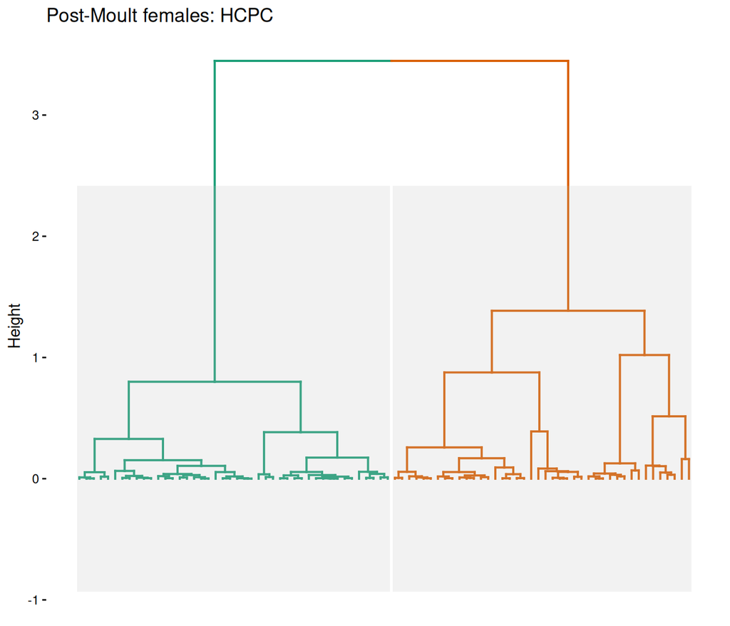

```r
fviz_dend(res.hcpc, cex = 0.5, palette = unname(PAL[seq_len(K)]), rect = TRUE,
          rect_fill = TRUE, show_labels = FALSE, main = "Post-Moult females: HCPC")
```

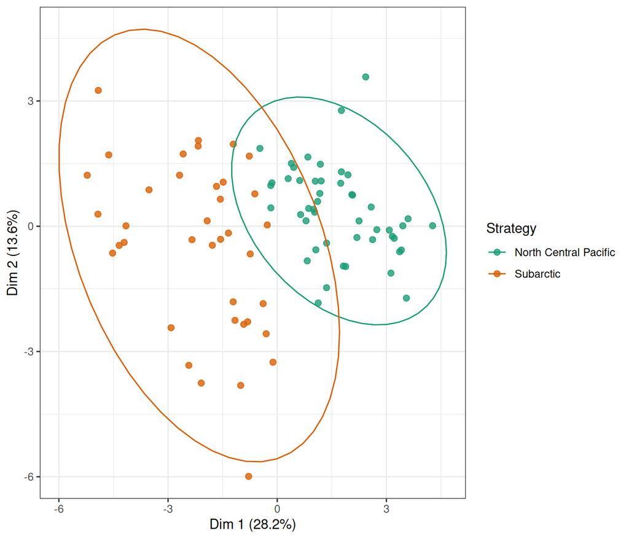

```r
g <- data.frame(Dim1 = S[, 1], Dim2 = S[, 2], strategy = dat$strategy) %>%
  ggplot(aes(Dim1, Dim2, colour = strategy)) +
  geom_point(size = 2, alpha = 0.8) + stat_ellipse(level = 0.95, type = "norm") +
  scale_colour_manual(values = COLS) + theme_bw() +
  labs(x = sprintf("Dim 1 (%.1f%%)", pc_tab$pct_var[1]),
       y = sprintf("Dim 2 (%.1f%%)", pc_tab$pct_var[2]), colour = "Strategy")
g
```

```r
ggsave(file.path(FIG, "A_factor_map.pdf"), g, width = 7, height = 5)
```

### 4.6.2 What characterises each strategy

`v.test` > 2 (or < −2) means the strategy mean is significantly above (below) the population mean. These tests are **descriptive**: the same variables built the clusters.

```r
desc <- res.hcpc$desc.var$quanti
names(desc) <- nm[as.integer(names(desc))]
lapply(desc, function(d)
  if (is.null(d)) "no variable differs from the population mean" else
    round(d[, c("v.test", "Mean in category", "Overall mean"), drop = FALSE], 2))
```

```
## $Subarctic
##                               v.test Mean in category Overall mean
## MaxLat_degrees                  6.88            52.67        49.00
## MesoEcoProportionSubArcticPac   6.38             0.77         0.55
## DeepDayForageDivesMedian_m      4.93          -597.11      -629.27
## MinLon_degrees                  3.73           206.25       200.26
## Pct_ForagingDives              -2.61            47.21        50.64
## Mean_Depth_sd                  -3.08           155.97       165.73
## Mean_Duration_sd               -3.30           397.04       424.80
## Mean_Depth_m                   -3.74           493.02       508.92
## Mean_Duration_sec              -4.88          1399.13      1473.58
## SdDistContShelf_km             -5.28           236.09       300.75
## MesoEcoProportionNorthCPac     -6.82             0.05         0.27
## MedianDistToContShelf_km       -7.25           487.58       792.81
##
## $`North Central Pacific`
##                               v.test Mean in category Overall mean
## MedianDistToContShelf_km        7.25          1034.44       792.81
## MesoEcoProportionNorthCPac      6.82             0.45         0.27
## SdDistContShelf_km              5.28           351.93       300.75
## Mean_Duration_sec               4.88          1532.51      1473.58
## Mean_Depth_m                    3.74           521.50       508.92
## Mean_Duration_sd                3.30           446.77       424.80
## Mean_Depth_sd                   3.08           173.45       165.73
## Pct_ForagingDives               2.61            53.37        50.64
## MinLon_degrees                 -3.73           195.51       200.26
## DeepDayForageDivesMedian_m     -4.93          -654.72      -629.27
## MesoEcoProportionSubArcticPac  -6.38             0.38         0.55
## MaxLat_degrees                 -6.88            46.09        49.00
```

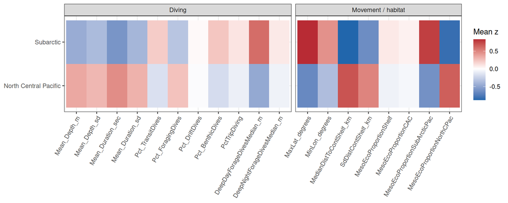

```r
prof <- data.frame(scale(dat[BEHAV]), strategy = dat$strategy) %>%
  pivot_longer(-strategy, names_to = "variable") %>%
  group_by(strategy, variable) %>% summarise(mean_z = mean(value), .groups = "drop") %>%
  mutate(block = ifelse(variable %in% SPACE, "Movement / habitat", "Diving"),
         variable = factor(variable, BEHAV))
g <- ggplot(prof, aes(variable, strategy, fill = mean_z)) + geom_tile() +
  facet_grid(~ block, scales = "free_x", space = "free_x") +
  scale_fill_gradient2(low = "#2166ac", high = "#b2182b") + theme_bw() +
  theme(axis.text.x = element_text(angle = 60, hjust = 1)) +
  labs(x = NULL, y = NULL, fill = "Mean z")
g
```

```r
ggsave(file.path(FIG, "A_strategy_profiles.pdf"), g, width = 11, height = 4.5)

# Mean (SD) of each variable by strategy
dat %>% group_by(strategy) %>%
  summarise(across(all_of(BEHAV), ~ sprintf("%.2f (%.2f)", mean(.x), sd(.x)))) %>%
  pivot_longer(-strategy, names_to = "variable") %>%
  pivot_wider(names_from = strategy, values_from = value)
```

```
## # A tibble: 19 × 3
##    variable                      `North Central Pacific` Subarctic
##    <chr>                         <chr>                   <chr>
##  1 MaxLat_degrees                46.09 (1.62)            52.67 (4.06)
##  2 MinLon_degrees                195.51 (8.52)           206.25 (15.66)
##  3 MedianDistToContShelf_km      1034.44 (156.13)        487.58 (273.34)
##  4 SdDistContShelf_km            351.93 (59.52)          236.09 (106.06)
##  5 MesoEcoProportionShelf        0.01 (0.02)             0.02 (0.03)
##  6 MesoEcoProportionCAC          0.16 (0.06)             0.17 (0.12)
##  7 MesoEcoProportionSubArcticPac 0.38 (0.23)             0.77 (0.16)
##  8 MesoEcoProportionNorthCPac    0.45 (0.24)             0.05 (0.08)
##  9 Mean_Depth_m                  521.50 (28.43)          493.02 (36.52)
## 10 Mean_Depth_sd                 173.45 (25.48)          155.97 (23.97)
## 11 Mean_Duration_sec             1532.51 (85.14)         1399.13 (130.11)
## 12 Mean_Duration_sd              446.77 (65.27)          397.04 (64.94)
## 13 Pct_TransitDives              27.90 (6.81)            31.01 (9.87)
## 14 Pct_ForagingDives             53.37 (8.48)            47.21 (12.60)
## 15 Pct_DriftDives                12.37 (5.78)            12.60 (4.59)
## 16 Pct_BenthicDives              0.06 (0.05)             0.09 (0.08)
## 17 PctTripDiving                 90.94 (0.73)            91.10 (1.00)
## 18 DeepDayForageDivesMedian_m    -654.72 (41.38)         -597.11 (50.66)
## 19 DeepNightForageDivesMedian_m  -484.49 (27.62)         -479.78 (31.12)
```

## 4.7 Sensitivity of the strategies

Each alternative is compared with the final partition with the adjusted Rand index (ARI = 1: identical; > 0.8: very similar).

```r
ari <- function(a, b) round(mclust::adjustedRandIndex(a, b), 3)
sens <- list()

for (nd in setdiff(c(N_DIM - 1, N_DIM + 1, length(BEHAV)), 1))
  sens[[paste("Dimensions =", nd)]] <- ari(cl, hcpc_lite(pc_scores(X, nd), K))

mfa <- MFA(X, group = c(length(SPACE), length(DIVE)), type = c("s", "s"),
           name.group = c("Space", "Diving"), ncp = N_DIM, graph = FALSE)
sens[["MFA (blocks weighted equally)"]] <- ari(cl, hcpc_lite(mfa$ind$coord[, 1:N_DIM], K))

sk <- names(which(abs(sapply(X, skew)) > SKEW_THRESHOLD & sapply(X, min) >= 0))
Xlog <- X; Xlog[sk] <- lapply(X[sk], function(x) log(x + max(min(x[x > 0]) / 2, 1e-6)))
sens[["Log-transform skewed variables"]] <- ari(cl, hcpc_lite(pc_scores(Xlog, N_DIM), K))

Xred <- X[setdiff(BEHAV, c("SdDistContShelf_km", "MesoEcoProportionNorthCPac"))]
sens[["Drop redundant SdDist + NorthCPac"]] <- ari(cl, hcpc_lite(pc_scores(Xred, N_DIM), K))

sens[["Ward without consolidation"]] <- ari(cl, cutree(hclust(dist(S), "ward.D2"), K))
set.seed(SEED)
sens[["k-means (100 starts)"]] <- ari(cl, kmeans(S, K, nstart = 100)$cluster)

md2 <- mahalanobis(S, colMeans(S), cov(S))
out <- md2 > qchisq(0.999, N_DIM)
cat("Multivariate outliers (p < 0.001):", paste(dat$TOPPID[out], collapse = ", "), "\n")
```

```
## Multivariate outliers (p < 0.001): 2016035
```

```r
if (any(out)) sens[["Without multivariate outliers"]] <-
  ari(cl[!out], hcpc_lite(pc_scores(X[!out, ], N_DIM), K))

one <- !duplicated(ifelse(is.na(dat$MainID), dat$TOPPID, dat$MainID))
sens[["One trip per seal"]] <- ari(cl[one], hcpc_lite(pc_scores(X[one, ], N_DIM), K))

sens_tab <- data.frame(scenario = names(sens), ARI = unlist(sens), row.names = NULL)
sens_tab
```

```
##                             scenario   ARI
## 1                     Dimensions = 3 1.000
## 2                     Dimensions = 5 0.864
## 3                    Dimensions = 19 0.864
## 4      MFA (blocks weighted equally) 0.864
## 5     Log-transform skewed variables 0.864
## 6  Drop redundant SdDist + NorthCPac 0.584
## 7         Ward without consolidation 0.821
## 8               k-means (100 starts) 0.864
## 9      Without multivariate outliers 0.862
## 10                 One trip per seal 0.857
```

```r
write.csv(sens_tab, file.path(OUT, "A_sensitivity.csv"), row.names = FALSE)

write.csv(dat %>% dplyr::select(TOPPID, MainID, ProcedureYear, strategy, silhouette, coassign),
          file.path(OUT, "A_strategy_assignments.csv"), row.names = FALSE)
```

## 4.8 Strategies and year

```r
table(dat$strategy, dat$ProcedureYear)
```

```
##
##                         2008 2009 2012 2013 2014 2015 2016 2017
##   North Central Pacific    8    8    6    7    8    1    5    5
##   Subarctic                3    1    7    7    6    2    6    6
```

```r
fisher.test(table(dat$strategy, dat$ProcedureYear), simulate.p.value = TRUE, B = 1e4)
```

```
##
##  Fisher's Exact Test for Count Data with simulated p-value (based on
##  10000 replicates)
##
## data:  table(dat$strategy, dat$ProcedureYear)
## p-value = 0.3683
## alternative hypothesis: two.sided
```

## 4.9 Comparison with the Post-Breeding strategies

For seals tracked on both trips, is the Post-Moult strategy related to the Post-Breeding one? Run `NESE_PB_ForagingStrategies.Rmd` first. Only a subset of seals have both trips, so treat this as exploratory. The PB and PM trips compared here need not be from the same year.

```r
if (file.exists(PB_ASSIGNMENTS)) {
  yr <- function(x) as.integer(as.character(x))
  pb <- read.csv(PB_ASSIGNMENTS) %>%
    mutate(MainID = as.character(MainID), PB_year = yr(ProcedureYear),
           PB_strategy = as.character(strategy)) %>%
    filter(!is.na(MainID)) %>% arrange(PB_year) %>%
    dplyr::select(MainID, TOPPID_PB = TOPPID, PB_year, PB_strategy)
  pm <- dat %>% filter(!is.na(MainID)) %>%
    transmute(MainID, TOPPID_PM = TOPPID, PM_year = yr(ProcedureYear),
              PM_strategy = as.character(strategy)) %>%
    arrange(PM_year)

  # All PB-PM trip pairs, for reference (seals with repeated trips appear more than once)
  print(inner_join(pm, pb, by = "MainID"))

  # Analysis unit = seal: earliest PM trip paired with earliest PB trip
  both <- inner_join(distinct(pm, MainID, .keep_all = TRUE),
                     distinct(pb, MainID, .keep_all = TRUE), by = "MainID")
  cat(nrow(both), "seals with both a PB and a PM trip (one pair per seal)\n")
  tab <- table(PB = both$PB_strategy, PM = both$PM_strategy)
  print(tab)
  if (nrow(both) >= 5 && all(dim(tab) > 1))
    print(fisher.test(tab, simulate.p.value = TRUE, B = 1e4))

  # Same offshore region on both trips? (seals whose PB strategy also exists after the moult)
  sh <- both %>% filter(PB_strategy %in% levels(dat$strategy))
  if (nrow(sh) >= 3) {
    obs <- sum(sh$PB_strategy == sh$PM_strategy)
    set.seed(SEED)
    null <- replicate(N_PERM, sum(sh$PB_strategy == sample(sh$PM_strategy)))
    cat(obs, "of", nrow(sh), "seals used the same region on both trips; expected by chance",
        round(mean(null), 1), "; P =", signif((1 + sum(null >= obs)) / (N_PERM + 1), 3), "\n")
  }
  write.csv(both, file.path(OUT, "A_PB_PM_per_seal.csv"), row.names = FALSE)
} else {
  message("PB assignments not found at ", PB_ASSIGNMENTS, ": run the PB script first.")
}
```

```
##    MainID TOPPID_PM PM_year           PM_strategy TOPPID_PB PB_year
## 1    1244   2007046    2008 North Central Pacific   2011012    2011
## 2    R148   2007048    2008 North Central Pacific   2009011    2009
## 3    R148   2007048    2008 North Central Pacific   2010035    2010
## 4     T35   2011043    2012 North Central Pacific   2011019    2011
## 5    U634   2011039    2012             Subarctic   2014018    2014
## 6    S126   2012043    2013 North Central Pacific   2009008    2009
## 7    S126   2012043    2013 North Central Pacific   2013019    2013
## 8    U754   2012037    2013 North Central Pacific   2013014    2013
## 9    4534   2013041    2014             Subarctic   2013016    2013
## 10   T220   2013045    2014 North Central Pacific   2011014    2011
## 11   U848   2013032    2014 North Central Pacific   2013005    2013
## 12   X387   2013043    2014             Subarctic   2013015    2013
## 13   4534   2014031    2015             Subarctic   2013016    2013
## 14   T220   2014033    2015 North Central Pacific   2011014    2011
```

[output cut: 36 more lines]

# 5 Part B — Isotopic niches of the strategies

Isotopes were not used to define the strategies, so differences here are an independent result. State which tissue was sampled and the period it integrates relative to the tracked trip. Isotopic baselines vary among years, so year is included as a covariate in the tests and checked in the sensitivity analysis.

## 5.1 Helper functions

```r
# Freedman-Lane permutation F test for `term`, adjusting for `covars`
fl_test <- function(d, response, term = "strategy", covars = character(0), B = N_PERM) {
  v  <- c(response, term, covars)
  d  <- d[complete.cases(d[v]), v, drop = FALSE]
  X0 <- model.matrix(reformulate(if (length(covars)) covars else "1"), d)
  X1 <- model.matrix(reformulate(c(covars, term)), d)
  y  <- d[[response]]
  Fstat <- function(y) {
    m0 <- lm.fit(X0, y); m1 <- lm.fit(X1, y)
    r0 <- sum(m0$residuals^2); r1 <- sum(m1$residuals^2)
    ((r0 - r1) / (m1$rank - m0$rank)) / (r1 / (nrow(X1) - m1$rank))
  }
  F_obs <- Fstat(y)
  m0 <- lm.fit(X0, y); fit0 <- y - m0$residuals
  F_p <- replicate(B, Fstat(fit0 + sample(m0$residuals)))
  data.frame(response = response,
             covariates = if (length(covars)) paste(covars, collapse = " + ") else "none",
             n = nrow(d), F = F_obs, p_perm = (1 + sum(F_p >= F_obs)) / (B + 1))
}

# All pairwise differences between strategies from an lm, with CIs
pair_contrasts <- function(fit, term = "strategy", level = 0.95) {
  b <- coef(fit); V <- vcov(fit)
  lev <- levels(model.frame(fit)[[term]]); cn <- paste0(term, lev)
  tq <- qt(1 - (1 - level) / 2, fit$df.residual)
  do.call(rbind, combn(seq_along(lev), 2, simplify = FALSE, FUN = function(ij) {
    L <- setNames(numeric(length(b)), names(b))
    if (cn[ij[2]] %in% names(b)) L[cn[ij[2]]] <- 1
    if (cn[ij[1]] %in% names(b)) L[cn[ij[1]]] <- L[cn[ij[1]]] - 1
    est <- sum(L * b); se <- sqrt(drop(t(L) %*% V %*% L))
    data.frame(contrast = paste(lev[ij[2]], "-", lev[ij[1]]),
               estimate = est, lwr = est - tq * se, upr = est + tq * se)
  }))
}

# Bayesian niche summaries (nicheROVER, default non-informative prior)
iso_niche <- function(d, nsamples = N_POST, seed = SEED) {
  set.seed(seed)
  par <- tapply(seq_len(nrow(d)), droplevels(d$strategy),
                function(ii) niw.post(nsamples = nsamples, X = as.matrix(d[ii, ISO])))
  nr95 <- sapply(par, function(sp) apply(sp$Sigma, 3, niche.size, alpha = 0.95))
  seab <- sapply(par, function(sp) apply(sp$Sigma, 3, function(Sg) pi * sqrt(det(Sg))))
  set.seed(seed)
  ov <- overlap(par, nreps = nsamples, nprob = nsamples, alpha = c(0.95, 0.99))
  list(par = par, nr95 = nr95, seab = seab, overlap = ov)
}
```

## 5.2 Isotopic values by strategy

```r
dat %>% group_by(strategy) %>%
  summarise(n = n(),
            d13C = sprintf("%.2f ± %.2f", mean(d13C), sd(d13C)),
            d15N = sprintf("%.2f ± %.2f", mean(d15N), sd(d15N)))
```

```
## # A tibble: 2 × 4
##   strategy                  n d13C          d15N
##   <fct>                 <int> <chr>         <chr>
## 1 North Central Pacific    48 -19.44 ± 0.21 14.63 ± 0.74
## 2 Subarctic                38 -19.50 ± 0.38 14.65 ± 1.02
```

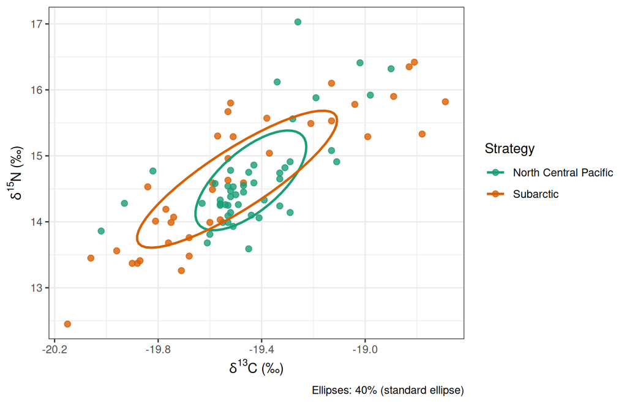

```r
g <- ggplot(dat, aes(d13C, d15N, colour = strategy)) +
  geom_point(size = 2, alpha = 0.8) +
  stat_ellipse(level = 0.40, type = "norm", linewidth = 0.9) +   # ~ standard ellipse
  scale_colour_manual(values = COLS) + theme_bw() +
  labs(x = expression(delta^{13}*C~"(‰)"), y = expression(delta^{15}*N~"(‰)"),
       colour = "Strategy", caption = "Ellipses: 40% (standard ellipse)")
g
```

```r
ggsave(file.path(FIG, "B_isotopes_by_strategy.pdf"), g, width = 7, height = 5, device = cairo_pdf)
```

## 5.3 Do strategies differ in isotopic values?

```r
set.seed(SEED)
iso_tests <- bind_rows(lapply(ISO, function(v) bind_rows(
  fl_test(dat, v), fl_test(dat, v, covars = "ProcedureYear"))))
iso_tests$p_BH <- p.adjust(iso_tests$p_perm, "BH")
iso_tests %>% mutate(across(c(F, p_perm, p_BH), ~ signif(.x, 3)))
```

```
##   response    covariates  n       F p_perm  p_BH
## 1     d13C          none 86 0.68200  0.400 0.926
## 2     d13C ProcedureYear 86 0.04280  0.839 0.926
## 3     d15N          none 86 0.00881  0.926 0.926
## 4     d15N ProcedureYear 86 0.25300  0.614 0.926
```

```r
fits <- lapply(setNames(ISO, ISO), function(v)
  lm(reformulate(c("strategy", "ProcedureYear"), v), data = dat))
contr <- bind_rows(lapply(fits, pair_contrasts), .id = "isotope")
contr %>% mutate(across(where(is.numeric), ~ round(.x, 3)))
```

```
##   isotope                          contrast estimate    lwr   upr
## 1    d13C Subarctic - North Central Pacific   -0.013 -0.142 0.115
## 2    d15N Subarctic - North Central Pacific    0.097 -0.286 0.479
```

```r
write.csv(bind_rows(iso_tests), file.path(OUT, "B_isotope_tests.csv"), row.names = FALSE)
write.csv(contr, file.path(OUT, "B_isotope_contrasts.csv"), row.names = FALSE)
```

### 5.3.1 Isotopic differences with K - 1, K and K + 1 strategies

```r
set.seed(SEED)
bind_rows(lapply(intersect(c(K - 1, K, K + 1), K_RANGE), function(k) {
  d <- dat; d$strategy <- factor(stab[[as.character(k)]]$ref)
  bind_rows(lapply(ISO, function(v) fl_test(d, v, covars = "ProcedureYear"))) %>% mutate(k = k)
})) %>% dplyr::select(k, response, n, F, p_perm) %>% mutate(across(c(F, p_perm), ~ signif(.x, 3)))
```

```
##   k response  n       F p_perm
## 1 2     d13C 86  0.0428 0.8320
## 2 2     d15N 86  0.2530 0.6200
## 3 3     d13C 86 20.0000 0.0002
## 4 3     d15N 86 18.4000 0.0002
```

### 5.3.2 Equivalence: are some strategies isotopically indistinguishable?

A non-significant test is not evidence of no difference. Two one-sided tests (TOST): two strategies are considered equivalent if the 90 % CI of their difference lies inside ±margin (`EQUIV`).

```r
tost <- bind_rows(lapply(ISO, function(v) {
  ci <- pair_contrasts(fits[[v]], level = 0.90)
  data.frame(isotope = v, ci, margin = EQUIV[[v]],
             equivalent = ci$lwr > -EQUIV[[v]] & ci$upr < EQUIV[[v]],
             different  = ci$lwr > 0 | ci$upr < 0)
}))
tost %>% mutate(across(where(is.numeric), ~ round(.x, 3)))
```

```
##   isotope                          contrast estimate    lwr   upr margin
## 1    d13C Subarctic - North Central Pacific   -0.013 -0.121 0.094    0.3
## 2    d15N Subarctic - North Central Pacific    0.097 -0.223 0.417    1.0
##   equivalent different
## 1       TRUE     FALSE
## 2       TRUE     FALSE
```

## 5.4 Isotopic niche size and overlap (nicheROVER)

nicheROVER is used with its **default, non-informative prior** and a fixed seed. Niche size is reported as the 95 % niche region (nicheROVER) and as the Bayesian standard ellipse area (SEA_B = π√|Σ|, comparable with SIBER); SEAc is the small-sample-corrected standard ellipse area from the data.

```r
nb <- iso_niche(dat)

sea_c <- tapply(seq_len(n), dat$strategy, function(ii) {
  m <- length(ii); pi * sqrt(det(cov(dat[ii, ISO]))) * (m - 1) / (m - 2) })
size_tab <- data.frame(strategy = levels(dat$strategy), n = as.vector(table(dat$strategy)),
  SEAc = as.vector(sea_c),
  SEAb_median = apply(nb$seab, 2, median),
  SEAb_lwr = apply(nb$seab, 2, quantile, 0.025), SEAb_upr = apply(nb$seab, 2, quantile, 0.975),
  NR95_median = apply(nb$nr95, 2, median),
  NR95_lwr = apply(nb$nr95, 2, quantile, 0.025), NR95_upr = apply(nb$nr95, 2, quantile, 0.975))
size_tab %>% mutate(across(where(is.double), ~ round(.x, 3)))
```

```
##                                    strategy  n  SEAc SEAb_median SEAb_lwr
## North Central Pacific North Central Pacific 48 0.374       0.353    0.271
## Subarctic                         Subarctic 38 0.641       0.597    0.444
##                       SEAb_upr NR95_median NR95_lwr NR95_upr
## North Central Pacific    0.476       2.118    1.623    2.850
## Subarctic                0.819       3.574    2.659    4.909
```

```r
write.csv(size_tab, file.path(OUT, "B_niche_size.csv"), row.names = FALSE)

# Posterior probability that the row strategy has a larger niche than the column strategy
lev <- levels(dat$strategy)
round(outer(lev, lev, Vectorize(function(a, b) mean(nb$seab[, a] > nb$seab[, b]))), 3) %>%
  `dimnames<-`(list(lev, lev))
```

```
##                       North Central Pacific Subarctic
## North Central Pacific                 0.000     0.006
## Subarctic                             0.994     0.000
```

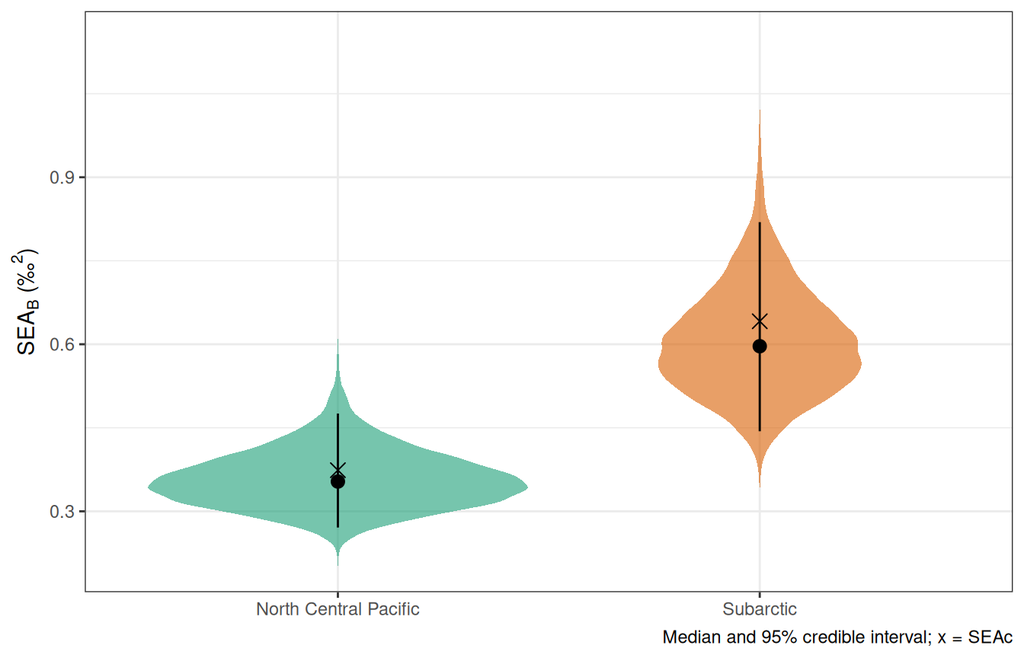

```r
g <- as.data.frame(nb$seab) %>% pivot_longer(everything(), names_to = "strategy") %>%
  mutate(strategy = factor(strategy, lev)) %>%
  ggplot(aes(strategy, value, fill = strategy)) +
  geom_violin(alpha = 0.6, colour = NA) +
  stat_summary(fun.data = function(x) data.frame(y = median(x), ymin = quantile(x, .025),
                                                 ymax = quantile(x, .975))) +
  geom_point(data = size_tab, aes(strategy, SEAc), shape = 4, size = 3, inherit.aes = FALSE) +
  scale_fill_manual(values = COLS, guide = "none") + theme_bw() +
  labs(x = NULL, y = expression("SEA"[B]~"(‰"^2*")"),
       caption = "Median and 95% credible interval; x = SEAc")
g
```

```r
ggsave(file.path(FIG, "B_niche_size.pdf"), g, width = 6, height = 4.5, device = cairo_pdf)
```

**Overlap.** Entry [row, column] is the probability (%) that an individual of the row strategy falls inside the 95 % niche region of the column strategy. Overlap is directional, so the two directions can differ.

```r
ov_mean <- apply(nb$overlap, c(1:2, 4), mean) * 100
ov_ci   <- apply(nb$overlap * 100, c(1:2, 4), quantile, prob = c(0.025, 0.975), na.rm = TRUE)
round(ov_mean[, , 1], 1)
```

```
##                        Species B
## Species A               North Central Pacific Subarctic
##   North Central Pacific                    NA      95.4
##   Subarctic                              74.6        NA
```

```r
round(ov_ci[, , , 1], 1)
```

```
## , , Species B = North Central Pacific
##
##        Species A
##         North Central Pacific Subarctic
##   2.5%                     NA      60.0
##   97.5%                    NA      87.6
##
## , , Species B = Subarctic
##
##        Species A
##         North Central Pacific Subarctic
##   2.5%                   87.3        NA
##   97.5%                  99.5        NA
```

```r
ov_long <- expand.grid(from = lev, into = lev, stringsAsFactors = FALSE) %>% filter(from != into) %>%
  mutate(mean = mapply(function(a, b) ov_mean[a, b, 1], from, into),
         lwr  = mapply(function(a, b) ov_ci[1, a, b, 1], from, into),
         upr  = mapply(function(a, b) ov_ci[2, a, b, 1], from, into))
write.csv(ov_long, file.path(OUT, "B_niche_overlap_95.csv"), row.names = FALSE)
```

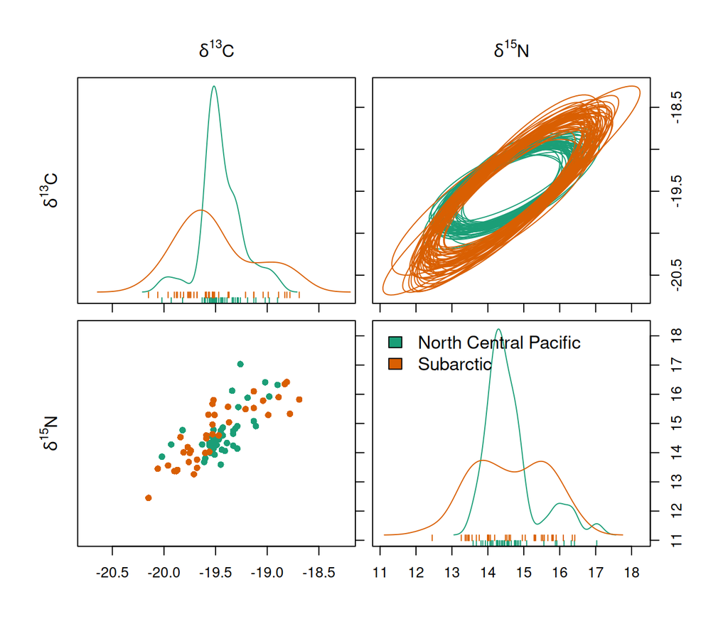

```r
set.seed(SEED)
par50 <- tapply(seq_len(n), dat$strategy,
                function(ii) niw.post(nsamples = 50, X = as.matrix(dat[ii, ISO])))
dat_l <- tapply(seq_len(n), dat$strategy, function(ii) as.matrix(dat[ii, ISO]))
niche.plot(niche.par = par50, niche.data = dat_l, pfrac = 0.05,
           iso.names = expression(delta^{13}*C, delta^{15}*N), col = unname(COLS))
```

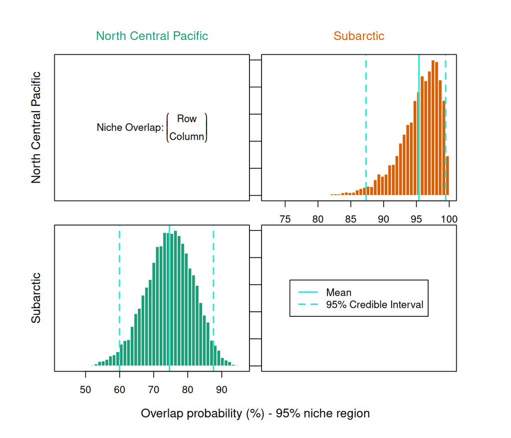

```r
overlap.plot(nb$overlap[, , , 1], col = unname(COLS), mean.cred.col = "turquoise",
             equal.axis = TRUE, xlab = "Overlap probability (%) - 95% niche region")
```

## 5.5 Isotopic niche size and overlap (SIBER)

SIBER (Jackson et al. 2011) gives the standard measures of isotopic niche width: the sample-size-corrected standard ellipse area (SEAc) and its Bayesian estimate (SEA_B, fitted in JAGS). Overlap is the **area** shared by two ellipses (here the 95 % ellipses), expressed as a proportion of the combined area (symmetric) and of each ellipse (directional). Unlike nicheROVER’s probabilistic overlap, it is purely geometric, so the two are not directly comparable. This section is skipped if JAGS is not installed.

```r
# SIBER needs columns iso1, iso2, group, community; simple group codes avoid
# problems with spaces in names (lookup table below)
codes <- setNames(paste0("S", seq_along(lev)), lev)
siber_df <- data.frame(iso1 = dat$d13C, iso2 = dat$d15N,
                       group = unname(codes[as.character(dat$strategy)]), community = 1)
siber <- SIBER::createSiberObject(siber_df)
ell_id <- paste0("1.", codes)                 # ellipse identifiers: "community.group"
names(ell_id) <- lev
data.frame(strategy = lev, code = codes, ellipse = ell_id, row.names = NULL)
```

```
##                strategy code ellipse
## 1 North Central Pacific   S1    1.S1
## 2             Subarctic   S2    1.S2
```

```r
# Maximum-likelihood metrics (TA = convex hull area, SEA, SEAc)
ml <- SIBER::groupMetricsML(siber)
colnames(ml) <- lev[match(colnames(ml), ell_id)]
round(ml, 3)
```

```
##      North Central Pacific Subarctic
## TA                   1.836     2.116
## SEA                  0.366     0.624
## SEAc                 0.374     0.641
```

```r
# Bayesian standard ellipses
set.seed(SEED)
ell_post <- SIBER::siberMVN(siber, SIBER_PARMS, SIBER_PRIORS)
sea_b_siber <- SIBER::siberEllipses(ell_post)
colnames(sea_b_siber) <- lev[match(names(ell_post), ell_id)]

siber_size <- data.frame(strategy = colnames(sea_b_siber),
  n = as.vector(table(dat$strategy)[colnames(sea_b_siber)]),
  SEAc = ml["SEAc", colnames(sea_b_siber)],
  SEAb_mode = apply(sea_b_siber, 2, function(x) { dd <- density(x); dd$x[which.max(dd$y)] }),
  SEAb_median = apply(sea_b_siber, 2, median),
  SEAb_lwr = apply(sea_b_siber, 2, quantile, 0.025),
  SEAb_upr = apply(sea_b_siber, 2, quantile, 0.975), row.names = NULL)
siber_size %>% mutate(across(where(is.double), ~ round(.x, 3)))
```

```
##                strategy  n  SEAc SEAb_mode SEAb_median SEAb_lwr SEAb_upr
## 1 North Central Pacific 48 0.374     0.348       0.375    0.284    0.506
## 2             Subarctic 38 0.641     0.665       0.679    0.500    0.950
```

```r
write.csv(siber_size, file.path(OUT, "B_SIBER_niche_size.csv"), row.names = FALSE)

# Posterior probability that the row strategy has a larger SEA_B than the column strategy
round(outer(colnames(sea_b_siber), colnames(sea_b_siber),
            Vectorize(function(a, b) mean(sea_b_siber[, a] > sea_b_siber[, b]))), 3) %>%
  `dimnames<-`(list(colnames(sea_b_siber), colnames(sea_b_siber)))
```

```
##                       North Central Pacific Subarctic
## North Central Pacific                 0.000     0.004
## Subarctic                             0.996     0.000
```

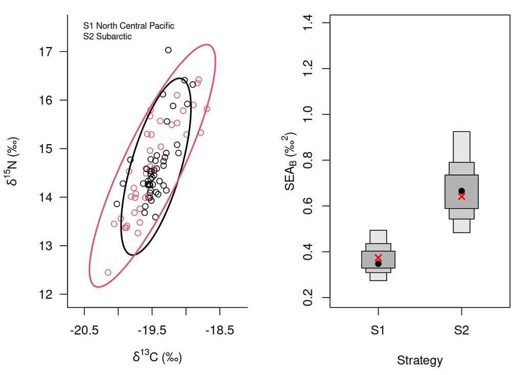

```r
par(mfrow = c(1, 2), mar = c(4.5, 4.5, 1, 1))
SIBER::plotSiberObject(siber, ax.pad = 0.5, hulls = FALSE, ellipses = TRUE,
                       group.ellipses.args = list(lty = 1, lwd = 2, p.interval = SIBER_P),
                       group.hulls = FALSE, bty = "L", iso.order = c(1, 2),
                       xlab = expression(delta^{13}*C~"(‰)"),
                       ylab = expression(delta^{15}*N~"(‰)"))
legend("topleft", legend = paste(codes, names(codes)), bty = "n", cex = 0.7)
SIBER::siberDensityPlot(sea_b_siber, xticklabels = codes[colnames(sea_b_siber)],
                        xlab = "Strategy", ylab = expression("SEA"[B]~"(‰"^2*")"))
points(seq_len(ncol(sea_b_siber)), siber_size$SEAc, col = "red", pch = 4, lwd = 2)
```

```r
par(mfrow = c(1, 1))
```

```r
pairs_s <- combn(lev, 2, simplify = FALSE)

# Maximum-likelihood overlap of the ellipses
ml_ov <- do.call(rbind, lapply(pairs_s, function(pr) {
  o <- SIBER::maxLikOverlap(ell_id[pr[1]], ell_id[pr[2]], siber, p.interval = SIBER_P, n = 100)
  data.frame(A = pr[1], B = pr[2], area_A = o[["area.1"]], area_B = o[["area.2"]],
             overlap_area = o[["overlap"]])
}))

# Bayesian overlap: one value per posterior draw
set.seed(SEED)
bayes_ov <- lapply(pairs_s, function(pr)
  SIBER::bayesianOverlap(ell_id[pr[1]], ell_id[pr[2]], ell_post,
                         draws = SIBER_DRAWS, p.interval = SIBER_P, n = 100))
names(bayes_ov) <- sapply(pairs_s, paste, collapse = " vs ")

q3 <- function(x) sprintf("%.2f (%.2f-%.2f)", median(x, na.rm = TRUE),
                          quantile(x, 0.025, na.rm = TRUE), quantile(x, 0.975, na.rm = TRUE))
siber_ov <- do.call(rbind, lapply(seq_along(pairs_s), function(i) {
  b <- bayes_ov[[i]]; pr <- pairs_s[[i]]
  ml_i <- ml_ov[i, ]
  data.frame(
    A = pr[1], B = pr[2],
    ML_prop_of_union = ml_i$overlap_area / (ml_i$area_A + ml_i$area_B - ml_i$overlap_area),
    Bayes_prop_of_union = q3(b$overlap / (b$area1 + b$area2 - b$overlap)),
    Bayes_prop_of_A = q3(b$overlap / b$area1),     # share of A's ellipse inside B's
    Bayes_prop_of_B = q3(b$overlap / b$area2))     # share of B's ellipse inside A's
}))
siber_ov %>% mutate(across(where(is.double), ~ round(.x, 3)))
```

```
##                       A         B ML_prop_of_union Bayes_prop_of_union
## 1 North Central Pacific Subarctic            0.545    0.46 (0.28-0.65)
##    Bayes_prop_of_A  Bayes_prop_of_B
## 1 0.91 (0.59-1.00) 0.48 (0.31-0.70)
```

```r
write.csv(siber_ov, file.path(OUT, "B_SIBER_overlap.csv"), row.names = FALSE)
```

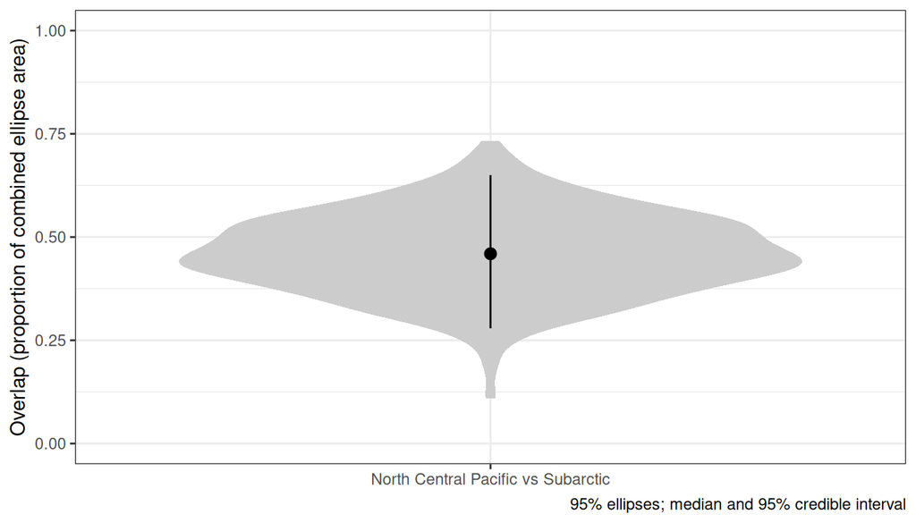

```r
g <- bind_rows(lapply(names(bayes_ov), function(nm) {
  b <- bayes_ov[[nm]]
  data.frame(pair = nm, prop = b$overlap / (b$area1 + b$area2 - b$overlap))
})) %>%
  ggplot(aes(pair, prop)) + geom_violin(fill = "grey80", colour = NA) +
  stat_summary(fun.data = function(x) data.frame(y = median(x), ymin = quantile(x, .025),
                                                 ymax = quantile(x, .975))) +
  coord_cartesian(ylim = c(0, 1)) + theme_bw() +
  labs(x = NULL, y = "Overlap (proportion of combined ellipse area)",
       caption = paste0(SIBER_P * 100, "% ellipses; median and 95% credible interval"))
g
```

```r
ggsave(file.path(FIG, "B_SIBER_overlap.pdf"), g, width = 7, height = 4)
```

## 5.6 Sensitivity of the isotopic results

- **One trip per seal** — removes repeated individuals.
- **High-confidence seals only** — bootstrap co-assignment ≥ `LOW_CONFIDENCE`.
- **Year-centred isotopes** — removes year-to-year baseline shifts. Note that this also removes any real difference between strategies that happen to be concentrated in particular years.

```r
iso_c <- dat %>% group_by(ProcedureYear) %>%
  mutate(across(all_of(ISO), ~ .x - mean(.x))) %>% ungroup() %>% as.data.frame()
subsets <- list(`All trips` = dat,
                `One trip per seal` = dat[one, ],
                `High-confidence seals` = dat[dat$coassign >= LOW_CONFIDENCE, ],
                `Year-centred isotopes` = iso_c)

summ_subset <- function(d, nsamples = 5000) {
  d$strategy <- droplevels(d$strategy)
  if (min(table(d$strategy)) < 4) return(NULL)
  nbx <- iso_niche(d, nsamples)
  ov  <- apply(nbx$overlap, c(1:2, 4), mean)[, , 1] * 100
  set.seed(SEED)
  tests <- sapply(ISO, function(v) fl_test(d, v, covars = "ProcedureYear", B = 1999)$p_perm)
  list(n = table(d$strategy),
       SEAb_median = round(apply(nbx$seab, 2, median), 3),
       overlap95 = round(ov, 1),
       p_strategy_given_year = signif(tests, 3))
}
sens_iso <- lapply(subsets, summ_subset)
sens_iso
```

```
## $`All trips`
## $`All trips`$n
##
## North Central Pacific             Subarctic
##                    48                    38
##
## $`All trips`$SEAb_median
## North Central Pacific             Subarctic
##                 0.354                 0.594
##
## $`All trips`$overlap95
##                        Species B
## Species A               North Central Pacific Subarctic
##   North Central Pacific                    NA      95.4
##   Subarctic                              74.7        NA
##
## $`All trips`$p_strategy_given_year
##  d13C  d15N
## 0.824 0.616
##
##
## $`One trip per seal`
## $`One trip per seal`$n
##
## North Central Pacific             Subarctic
##                    46                    36
##
## $`One trip per seal`$SEAb_median
## North Central Pacific             Subarctic
##                 0.356                 0.606
##
## $`One trip per seal`$overlap95
##                        Species B
## Species A               North Central Pacific Subarctic
##   North Central Pacific                    NA      95.4
##   Subarctic                              74.1        NA
##
## $`One trip per seal`$p_strategy_given_year
##  d13C  d15N
## 0.990 0.597
```

[output cut: 27 more lines]

```
##                    48                    38
##
## $`Year-centred isotopes`$SEAb_median
## North Central Pacific             Subarctic
##                 0.316                 0.429
##
## $`Year-centred isotopes`$overlap95
##                        Species B
## Species A               North Central Pacific Subarctic
##   North Central Pacific                    NA      91.6
##   Subarctic                              79.1        NA
##
## $`Year-centred isotopes`$p_strategy_given_year
##  d13C  d15N
## 0.824 0.616
```

# 6 Part C — Post-Moult behaviour as a continuum

Post-moult groups are only weakly separated (Section “Is there cluster structure at all?”), so the more natural analysis is to relate isotopes to each seal’s **position along the behavioural gradient** (its scores on the retained PCA axes) rather than to group labels. If the gradient explains isotopes better than the two modes do, post-moult foraging is best described as a continuum.

## 6.1 The behavioural gradient

```r
G <- as.data.frame(res.pca$ind$coord[, 1:N_DIM]); names(G) <- paste0("Dim", 1:N_DIM)
DIMS <- names(G)
gd <- cbind(dat[, c("TOPPID", "MainID", "ProcedureYear", "strategy", ISO, "MesoEcoProportionCAC")], G)
cac_min <- min(gd$MesoEcoProportionCAC[gd$MesoEcoProportionCAC > 0])
gd$logCAC <- log(gd$MesoEcoProportionCAC + cac_min / 2)

# What each axis represents (variable-axis correlations, |r| >= 0.5)
cor_tab <- res.pca$var$cor[, 1:N_DIM]; colnames(cor_tab) <- DIMS
lapply(setNames(DIMS, DIMS), function(d) { r <- cor_tab[, d]; round(sort(r[abs(r) >= 0.5]), 2) })
```

```
## $Dim1
##                MaxLat_degrees MesoEcoProportionSubArcticPac
##                         -0.88                         -0.86
##    DeepDayForageDivesMedian_m                  Mean_Depth_m
##                         -0.62                          0.51
##             Mean_Duration_sec             Pct_ForagingDives
##                          0.51                          0.56
##            SdDistContShelf_km    MesoEcoProportionNorthCPac
##                          0.70                          0.86
##      MedianDistToContShelf_km
##                          0.87
##
## $Dim2
##    Pct_ForagingDives MesoEcoProportionCAC       MinLon_degrees
##                -0.65                -0.63                -0.62
##     Pct_BenthicDives        Mean_Depth_sd
##                 0.53                 0.58
##
## $Dim3
## Pct_TransitDives     Mean_Depth_m
##            -0.75            -0.56
##
## $Dim4
##      Mean_Depth_m  Mean_Duration_sd     PctTripDiving Mean_Duration_sec
##              0.51              0.55              0.59              0.60
```

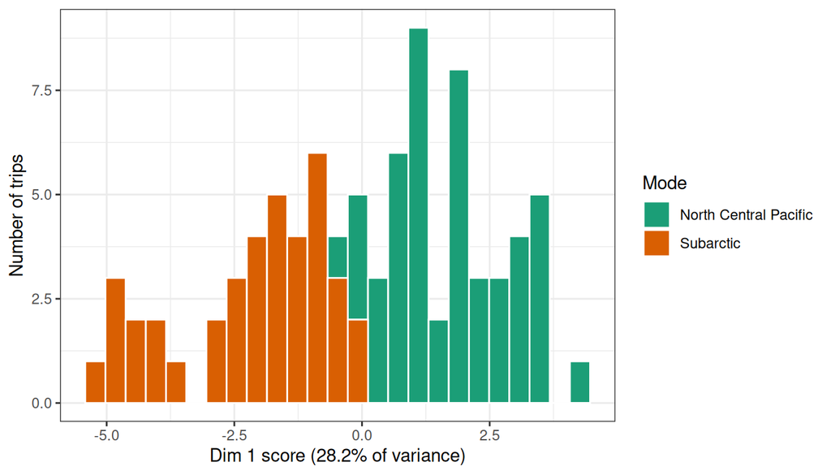

```r
g <- ggplot(gd, aes(Dim1, fill = strategy)) + geom_histogram(bins = 25, colour = "white") +
  scale_fill_manual(values = COLS) + theme_bw() +
  labs(x = sprintf("Dim 1 score (%.1f%% of variance)", pc_tab$pct_var[1]),
       y = "Number of trips", fill = "Mode")
g
```

```r
ggsave(file.path(FIG, "C_gradient_distribution.pdf"), g, width = 7, height = 4)

# Hartigan's dip test of unimodality along the main axis (needs the 'diptest' package)
if (requireNamespace("diptest", quietly = TRUE)) diptest::dip.test(gd$Dim1) else
  message("Install the 'diptest' package for a formal test of unimodality.")
```

```
##
##  Hartigans' dip test for unimodality / multimodality
##
## data:  gd$Dim1
## D = 0.031612, p-value = 0.8117
## alternative hypothesis: non-unimodal, i.e., at least bimodal
```

## 6.2 Do isotopes vary along the gradient?

Each axis is tested while adjusting for the other axes and for year (Freedman–Lane permutation tests), so each test asks whether that dimension of behaviour explains isotopic variation on its own.

```r
set.seed(SEED)
grad_tests <- bind_rows(lapply(ISO, function(v) bind_rows(lapply(DIMS, function(d)
  fl_test(gd, v, term = d, covars = c(setdiff(DIMS, d), "ProcedureYear")) %>% mutate(term = d)))))
grad_tests$p_BH <- p.adjust(grad_tests$p_perm, "BH")
grad_tests %>% dplyr::select(response, term, n, F, p_perm, p_BH) %>%
  mutate(across(c(F, p_perm, p_BH), ~ signif(.x, 3)))
```

```
##   response term  n        F p_perm   p_BH
## 1     d13C Dim1 86 5.80e+00 0.0166 0.0332
## 2     d13C Dim2 86 3.04e+01 0.0002 0.0008
## 3     d13C Dim3 86 6.86e-04 0.9800 0.9800
## 4     d13C Dim4 86 4.98e+00 0.0306 0.0490
## 5     d15N Dim1 86 6.93e+00 0.0084 0.0224
## 6     d15N Dim2 86 4.79e+01 0.0002 0.0008
## 7     d15N Dim3 86 9.26e-02 0.7640 0.8730
## 8     d15N Dim4 86 1.36e-01 0.7110 0.8730
```

```r
# Slopes (permil per unit of axis score) with 95% CIs
grad_fits <- lapply(setNames(ISO, ISO), function(v)
  lm(reformulate(c(DIMS, "ProcedureYear"), v), data = gd))
grad_slopes <- bind_rows(lapply(names(grad_fits), function(v) {
  f <- grad_fits[[v]]; ci <- confint(f)[DIMS, , drop = FALSE]
  data.frame(isotope = v, axis = DIMS, slope = unname(coef(f)[DIMS]),
             lwr = unname(ci[, 1]), upr = unname(ci[, 2]))
}))
grad_slopes %>% mutate(across(where(is.double), ~ round(.x, 3)))
```

```
##   isotope axis  slope    lwr    upr
## 1    d13C Dim1  0.028  0.005  0.051
## 2    d13C Dim2 -0.096 -0.131 -0.061
## 3    d13C Dim3  0.000 -0.035  0.034
## 4    d13C Dim4 -0.043 -0.081 -0.005
## 5    d15N Dim1  0.086  0.021  0.151
## 6    d15N Dim2 -0.341 -0.440 -0.243
## 7    d15N Dim3 -0.015 -0.114  0.083
## 8    d15N Dim4 -0.020 -0.128  0.088
```

```r
write.csv(grad_tests, file.path(OUT, "C_isotopes_vs_gradient_tests.csv"), row.names = FALSE)
write.csv(grad_slopes, file.path(OUT, "C_isotopes_vs_gradient_slopes.csv"), row.names = FALSE)
```

California Current use is the clearest single behavioural correlate of isotopic enrichment in both trips, so it is also tested directly (log scale, adjusting for year).

```r
set.seed(SEED)
cac_tests <- bind_rows(lapply(ISO, function(v) fl_test(gd, v, term = "logCAC", covars = "ProcedureYear")))
cac_tests %>% mutate(across(c(F, p_perm), ~ signif(.x, 3)))
```

```
##   response    covariates  n    F p_perm
## 1     d13C ProcedureYear 86 22.1  2e-04
## 2     d15N ProcedureYear 86 37.0  2e-04
```

```r
sapply(setNames(ISO, ISO), function(v)
  round(cor(gd[[v]], gd$MesoEcoProportionCAC, method = "spearman"), 3))
```

```
##  d13C  d15N
## 0.455 0.486
```

## 6.3 Groups or gradient? Model comparison

Lower AICc = better support (ΔAICc > 2 is a meaningful difference).

```r
aicc <- function(f) { k <- attr(logLik(f), "df"); m <- nobs(f); AIC(f) + 2 * k * (k + 1) / (m - k - 1) }
forms <- list(`Year only`              = "ProcedureYear",
              `Two modes (groups)`     = c("strategy", "ProcedureYear"),
              `Main axis (Dim 1)`      = c("Dim1", "ProcedureYear"),
              `All retained axes`      = c(DIMS, "ProcedureYear"),
              `California Current use` = c("logCAC", "ProcedureYear"))
cmp <- bind_rows(lapply(ISO, function(v) bind_rows(lapply(names(forms), function(nm) {
  f <- lm(reformulate(forms[[nm]], v), data = gd)
  data.frame(isotope = v, model = nm, n_par = attr(logLik(f), "df"), AICc = aicc(f),
             adj_R2 = summary(f)$adj.r.squared)
})) %>% mutate(delta_AICc = AICc - min(AICc)) %>% arrange(delta_AICc)))
cmp %>% mutate(across(where(is.double), ~ round(.x, 3)))
```

```
##    isotope                  model n_par    AICc adj_R2 delta_AICc
## 1     d13C      All retained axes    13  11.482  0.385      0.000
## 2     d13C California Current use    10  19.736  0.285      8.254
## 3     d13C      Main axis (Dim 1)    10  38.633  0.109     27.151
## 4     d13C              Year only     9  38.876  0.091     27.394
## 5     d13C     Two modes (groups)    10  41.393  0.080     29.911
## 6     d15N      All retained axes    13 190.673  0.427      0.000
## 7     d15N California Current use    10 195.028  0.363      4.355
## 8     d15N      Main axis (Dim 1)    10 226.078  0.086     35.405
## 9     d15N              Year only     9 226.241  0.069     35.569
## 10    d15N     Two modes (groups)    10 228.524  0.060     37.851
```

```r
write.csv(cmp, file.path(OUT, "C_groups_vs_gradient_AICc.csv"), row.names = FALSE)
```

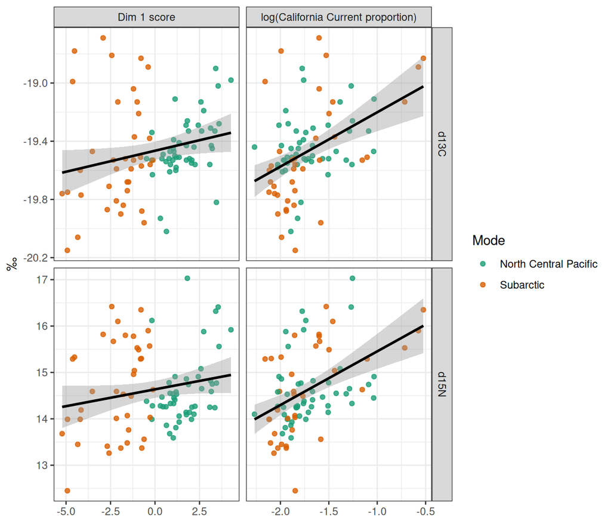

```r
gp <- gd %>% dplyr::select(strategy, all_of(ISO), Dim1, logCAC) %>%
  pivot_longer(all_of(ISO), names_to = "isotope", values_to = "value") %>%
  pivot_longer(c(Dim1, logCAC), names_to = "gradient", values_to = "x")
g <- ggplot(gp, aes(x, value)) +
  geom_point(aes(colour = strategy), alpha = 0.8) +
  geom_smooth(method = "lm", formula = y ~ x, colour = "black") +
  facet_grid(isotope ~ gradient, scales = "free",
             labeller = labeller(gradient = c(Dim1 = "Dim 1 score",
                                              logCAC = "log(California Current proportion)"))) +
  scale_colour_manual(values = COLS) + theme_bw() +
  labs(x = NULL, y = "‰", colour = "Mode")
g
```

```r
ggsave(file.path(FIG, "C_isotopes_vs_gradient.pdf"), g, width = 8, height = 6, device = cairo_pdf)
```

**Interpretation.** Evidence for a continuum: (i) weak cluster structure (null-model p close to 0.05), (ii) a unimodal or only weakly bimodal main axis, and (iii) isotopes explained by position along the gradient (or by California Current use) at least as well as by group membership. If so, describe post-moult foraging as continuous variation along the offshore–latitudinal gradient, with the two modes as convenient summaries rather than strategies.